[figure not shown]

Copyright by Pierian Data Inc.

Created by Jose Marcial Portilla.

# Keras API Project Exercise

## The Data

We will be using a subset of the LendingClub DataSet obtained from Kaggle: https://www.kaggle.com/wordsforthewise/lending-club

## NOTE: Do not download the full zip from the link! We provide a special version of this file that has some extra feature engineering for you to do. You won't be able to follow along with the original file!

LendingClub is a US peer-to-peer lending company, headquartered in San Francisco, California.[3] It was the first peer-to-peer lender to register its offerings as securities with the Securities and Exchange Commission (SEC), and to offer loan trading on a secondary market. LendingClub is the world's largest peer-to-peer lending platform.

### Our Goal

Given historical data on loans given out with information on whether or not the borrower defaulted (charge-off), can we build a model thatcan predict wether or nor a borrower will pay back their loan? This way in the future when we get a new potential customer we can assess whether or not they are likely to pay back the loan. Keep in mind classification metrics when evaluating the performance of your model!

The "loan_status" column contains our label.

### Data Overview

There are many LendingClub data sets on Kaggle. Here is the information on this particular data set:

|  | LoanStatNew | Description |
| --- | --- | --- |
| 0 | loan_amnt | The listed amount of the loan applied for by the borrower. If at some point in time, the credit department reduces the loan amount, then it will be reflected in this value. |
| 1 | term | The number of payments on the loan. Values are in months and can be either 36 or 60. |
| 2 | int_rate | Interest Rate on the loan |
| 3 | installment | The monthly payment owed by the borrower if the loan originates. |
| 4 | grade | LC assigned loan grade |
| 5 | sub_grade | LC assigned loan subgrade |
| 6 | emp_title | The job title supplied by the Borrower when applying for the loan.* |
| 7 | emp_length | Employment length in years. Possible values are between 0 and 10 where 0 means less than one year and 10 means ten or more years. |
| 8 | home_ownership | The home ownership status provided by the borrower during registration or obtained from the credit report. Our values are: RENT, OWN, MORTGAGE, OTHER |
| 9 | annual_inc | The self-reported annual income provided by the borrower during registration. |
| 10 | verification_status | Indicates if income was verified by LC, not verified, or if the income source was verified |
| 11 | issue_d | The month which the loan was funded |
| 12 | loan_status | Current status of the loan |
| 13 | purpose | A category provided by the borrower for the loan request. |
| 14 | title | The loan title provided by the borrower |
| 15 | zip_code | The first 3 numbers of the zip code provided by the borrower in the loan application. |
| 16 | addr_state | The state provided by the borrower in the loan application |
| 17 | dti | A ratio calculated using the borrower’s total monthly debt payments on the total debt obligations, excluding mortgage and the requested LC loan, divided by the borrower’s self-reported monthly income. |
| 18 | earliest_cr_line | The month the borrower's earliest reported credit line was opened |
| 19 | open_acc | The number of open credit lines in the borrower's credit file. |
| 20 | pub_rec | Number of derogatory public records |
| 21 | revol_bal | Total credit revolving balance |
| 22 | revol_util | Revolving line utilization rate, or the amount of credit the borrower is using relative to all available revolving credit. |
| 23 | total_acc | The total number of credit lines currently in the borrower's credit file |
| 24 | initial_list_status | The initial listing status of the loan. Possible values are – W, F |
| 25 | application_type | Indicates whether the loan is an individual application or a joint application with two co-borrowers |
| 26 | mort_acc | Number of mortgage accounts. |
| 27 | pub_rec_bankruptcies | Number of public record bankruptcies |

## Starter Code

#### Note: We also provide feature information on the data as a .csv file for easy lookup throughout the notebook:

```python
import pandas as pd
```

```python
data_info = pd.read_csv('../DATA/lending_club_info.csv',index_col='LoanStatNew')
```

```python
print(data_info.loc['revol_util']['Description'])
```

```
Revolving line utilization rate, or the amount of credit the borrower is using relative to all available revolving credit.
```

```python
def feat_info(col_name):
    print(data_info.loc[col_name]['Description'])
```

```python
feat_info('mort_acc')
```

```
Number of mortgage accounts.
```

## Loading the data and other imports

```python
import pandas as pd
import numpy as np
import matplotlib.pyplot as plt
import seaborn as sns

# might be needed depending on your version of Jupyter
%matplotlib inline
```

```python
df = pd.read_csv('../DATA/lending_club_loan_two.csv')
```

```python
df.isnull().sum()
```

```
loan_amnt                   0
term                        0
int_rate                    0
installment                 0
grade                       0
sub_grade                   0
emp_title               22927
emp_length              18301
home_ownership              0
annual_inc                  0
verification_status         0
issue_d                     0
loan_status                 0
purpose                     0
title                    1755
dti                         0
earliest_cr_line            0
open_acc                    0
pub_rec                     0
revol_bal                   0
revol_util                276
total_acc                   0
initial_list_status         0
application_type            0
mort_acc                37795
pub_rec_bankruptcies      535
address                     0
dtype: int64
```

```python
df.info()
```

```
<class 'pandas.core.frame.DataFrame'>
RangeIndex: 396030 entries, 0 to 396029
Data columns (total 27 columns):
 #   Column                Non-Null Count   Dtype
---  ------                --------------   -----
 0   loan_amnt             396030 non-null  float64
 1   term                  396030 non-null  object
 2   int_rate              396030 non-null  float64
 3   installment           396030 non-null  float64
 4   grade                 396030 non-null  object
 5   sub_grade             396030 non-null  object
 6   emp_title             373103 non-null  object
 7   emp_length            377729 non-null  object
 8   home_ownership        396030 non-null  object
 9   annual_inc            396030 non-null  float64
```

[output cut: 19 more lines]

# Project Tasks

**Complete the tasks below! Keep in mind there is usually more than one way to complete the task! Enjoy**

# Section 1: Exploratory Data Analysis

**OVERALL GOAL: Get an understanding for which variables are important, view summary statistics, and visualise the data**

**TASK: Since we will be attempting to predict loan_status, create a countplot as shown below.**

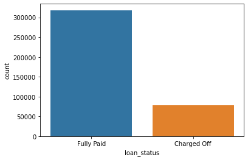

```python
sns.countplot(x='loan_status',data=df)
```

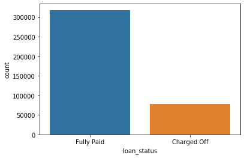

**TASK: Create a histogram of the loan_amnt column.**

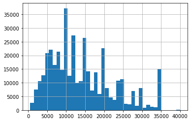

```python
df['loan_amnt'].hist(bins=40)
```

Okay, interesting - my straight hist worked, but it's not so pretty. Here's the solution code:

```
(0.0, 45000.0)
```

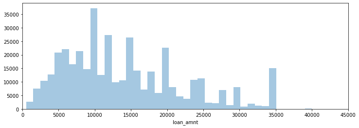

```python
plt.figure(figsize=(12,4)) #fine, yep, set the size
sns.distplot(df['loan_amnt'],kde=False,bins=40) #use seaborn... same bins as me, no kde line - oh, and note that
#it tells me to use displot, or histplot, not distplot.
plt.xlim(0,45000) #this, I don't know. What happens if I run it without it? Okay, here is with all the solution code
```

Here's code using the suggested displot - ends up all squished

```
(0.0, 45000.0)
```

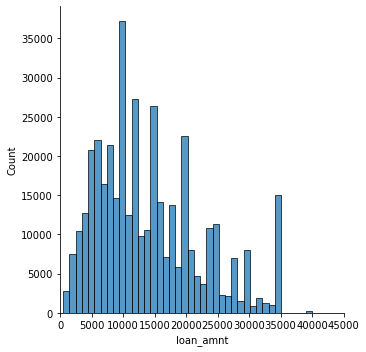

```python
plt.figure(figsize=(12,4))
sns.displot(df['loan_amnt'],kde=False,bins=40) #changed to displot
plt.xlim(0,45000)
```

Trying the suggested histplot, which looks nicer

```
(0.0, 45000.0)
```

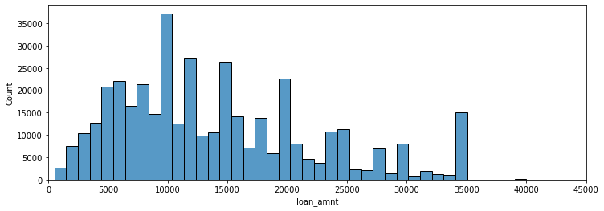

```python
plt.figure(figsize=(12,4))
sns.histplot(df['loan_amnt'],kde=False,bins=40) #changed to histplot
plt.xlim(0,45000)
```

And now I'll try without that mysterious last line - I can't see the difference? no doubt it'll be explained in the video later

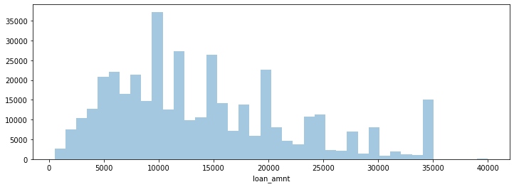

```python
plt.figure(figsize=(12,4))
sns.distplot(df['loan_amnt'],kde=False,bins=40)
# plt.xlim(0,45000)
```

plt.figure(figsize=(12,4)) sns.distplot(df['loan_amnt'],kde=False,bins=40) plt.xlim(0,45000)

**TASK: Let's explore correlation between the continuous feature variables. Calculate the correlation between all continuous numeric variables using .corr() method.**

```python
df.corr()
```

|  | loan_amnt | int_rate | installment | annual_inc | dti | open_acc | pub_rec | revol_bal | revol_util | total_acc | mort_acc | pub_rec_bankruptcies |
| --- | --- | --- | --- | --- | --- | --- | --- | --- | --- | --- | --- | --- |
| loan_amnt | 1.000000 | 0.168921 | 0.953929 | 0.336887 | 0.016636 | 0.198556 | -0.077779 | 0.328320 | 0.099911 | 0.223886 | 0.222315 | -0.106539 |
| int_rate | 0.168921 | 1.000000 | 0.162758 | -0.056771 | 0.079038 | 0.011649 | 0.060986 | -0.011280 | 0.293659 | -0.036404 | -0.082583 | 0.057450 |
| installment | 0.953929 | 0.162758 | 1.000000 | 0.330381 | 0.015786 | 0.188973 | -0.067892 | 0.316455 | 0.123915 | 0.202430 | 0.193694 | -0.098628 |
| annual_inc | 0.336887 | -0.056771 | 0.330381 | 1.000000 | -0.081685 | 0.136150 | -0.013720 | 0.299773 | 0.027871 | 0.193023 | 0.236320 | -0.050162 |
| dti | 0.016636 | 0.079038 | 0.015786 | -0.081685 | 1.000000 | 0.136181 | -0.017639 | 0.063571 | 0.088375 | 0.102128 | -0.025439 | -0.014558 |
| open_acc | 0.198556 | 0.011649 | 0.188973 | 0.136150 | 0.136181 | 1.000000 | -0.018392 | 0.221192 | -0.131420 | 0.680728 | 0.109205 | -0.027732 |
| pub_rec | -0.077779 | 0.060986 | -0.067892 | -0.013720 | -0.017639 | -0.018392 | 1.000000 | -0.101664 | -0.075910 | 0.019723 | 0.011552 | 0.699408 |
| revol_bal | 0.328320 | -0.011280 | 0.316455 | 0.299773 | 0.063571 | 0.221192 | -0.101664 | 1.000000 | 0.226346 | 0.191616 | 0.194925 | -0.124532 |
| revol_util | 0.099911 | 0.293659 | 0.123915 | 0.027871 | 0.088375 | -0.131420 | -0.075910 | 0.226346 | 1.000000 | -0.104273 | 0.007514 | -0.086751 |
| total_acc | 0.223886 | -0.036404 | 0.202430 | 0.193023 | 0.102128 | 0.680728 | 0.019723 | 0.191616 | -0.104273 | 1.000000 | 0.381072 | 0.042035 |
| mort_acc | 0.222315 | -0.082583 | 0.193694 | 0.236320 | -0.025439 | 0.109205 | 0.011552 | 0.194925 | 0.007514 | 0.381072 | 1.000000 | 0.027239 |
| pub_rec_bankruptcies | -0.106539 | 0.057450 | -0.098628 | -0.050162 | -0.014558 | -0.027732 | 0.699408 | -0.124532 | -0.086751 | 0.042035 | 0.027239 | 1.000000 |

|  | loan_amnt | int_rate | installment | annual_inc | dti | open_acc | pub_rec | revol_bal | revol_util | total_acc | mort_acc | pub_rec_bankruptcies |
| --- | --- | --- | --- | --- | --- | --- | --- | --- | --- | --- | --- | --- |
| loan_amnt | 1.000000 | 0.168921 | 0.953929 | 0.336887 | 0.016636 | 0.198556 | -0.077779 | 0.328320 | 0.099911 | 0.223886 | 0.222315 | -0.106539 |
| int_rate | 0.168921 | 1.000000 | 0.162758 | -0.056771 | 0.079038 | 0.011649 | 0.060986 | -0.011280 | 0.293659 | -0.036404 | -0.082583 | 0.057450 |
| installment | 0.953929 | 0.162758 | 1.000000 | 0.330381 | 0.015786 | 0.188973 | -0.067892 | 0.316455 | 0.123915 | 0.202430 | 0.193694 | -0.098628 |
| annual_inc | 0.336887 | -0.056771 | 0.330381 | 1.000000 | -0.081685 | 0.136150 | -0.013720 | 0.299773 | 0.027871 | 0.193023 | 0.236320 | -0.050162 |
| dti | 0.016636 | 0.079038 | 0.015786 | -0.081685 | 1.000000 | 0.136181 | -0.017639 | 0.063571 | 0.088375 | 0.102128 | -0.025439 | -0.014558 |
| open_acc | 0.198556 | 0.011649 | 0.188973 | 0.136150 | 0.136181 | 1.000000 | -0.018392 | 0.221192 | -0.131420 | 0.680728 | 0.109205 | -0.027732 |
| pub_rec | -0.077779 | 0.060986 | -0.067892 | -0.013720 | -0.017639 | -0.018392 | 1.000000 | -0.101664 | -0.075910 | 0.019723 | 0.011552 | 0.699408 |
| revol_bal | 0.328320 | -0.011280 | 0.316455 | 0.299773 | 0.063571 | 0.221192 | -0.101664 | 1.000000 | 0.226346 | 0.191616 | 0.194925 | -0.124532 |
| revol_util | 0.099911 | 0.293659 | 0.123915 | 0.027871 | 0.088375 | -0.131420 | -0.075910 | 0.226346 | 1.000000 | -0.104273 | 0.007514 | -0.086751 |
| total_acc | 0.223886 | -0.036404 | 0.202430 | 0.193023 | 0.102128 | 0.680728 | 0.019723 | 0.191616 | -0.104273 | 1.000000 | 0.381072 | 0.042035 |
| mort_acc | 0.222315 | -0.082583 | 0.193694 | 0.236320 | -0.025439 | 0.109205 | 0.011552 | 0.194925 | 0.007514 | 0.381072 | 1.000000 | 0.027239 |
| pub_rec_bankruptcies | -0.106539 | 0.057450 | -0.098628 | -0.050162 | -0.014558 | -0.027732 | 0.699408 | -0.124532 | -0.086751 | 0.042035 | 0.027239 | 1.000000 |

**TASK: Visualize this using a heatmap. Depending on your version of matplotlib, you may need to manually adjust the heatmap.**

- [Heatmap info](https://seaborn.pydata.org/generated/seaborn.heatmap.html#seaborn.heatmap)
- [Help with resizing](https://stackoverflow.com/questions/56942670/matplotlib-seaborn-first-and-last-row-cut-in-half-of-heatmap-plot)

sns.heatmap(df) #okay, so this doesn't work because there are strings in some fields. So I need to look at just numeric fields..

Below is the solution text - sizing the figure, and only looking at df.corr(). Okay. what's the 'annot'? Seaborn documentations says "annotbool or rectangular dataset, optional If True, write the data value in each cell. If an array-like with the same shape as data, then use this to annotate the heatmap instead of the data. Note that DataFrames will match on position, not index." Oh, right, it's just adding the numbers into the squares. cmap is the colour scheme - I'll do a different one. plt.ylim is clearly related to the plt.xlim of the last one. Mais c'est quoi? Aha! it's to do with sizing, as seaborn tends to chop off part of the last squares. Okay, cool

```
(10.0, 0.0)
```

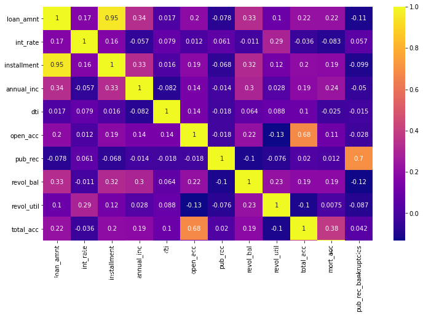

```python
plt.figure(figsize=(12,7))
sns.heatmap(df.corr(),annot=True,cmap='plasma')
plt.ylim(10, 0)
```

```
(10, 0)
```

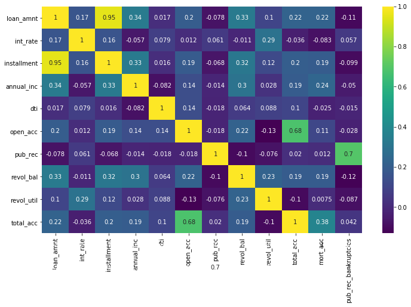

**TASK: You should have noticed almost perfect correlation with the "installment" feature. Explore this feature further. Print out their descriptions and perform a scatterplot between them. Does this relationship make sense to you? Do you think there is duplicate information here?**

```python
This is using the function set up in line 4, to pull out the drecription of each feature.
```

```python
feat_info('installment')
```

```
The monthly payment owed by the borrower if the loan originates.
```

```
The monthly payment owed by the borrower if the loan originates.
```

```python
feat_info('loan_amnt')
```

```
The listed amount of the loan applied for by the borrower. If at some point in time, the credit department reduces the loan amount, then it will be reflected in this value.
```

```
The listed amount of the loan applied for by the borrower. If at some point in time, the credit department reduces the loan amount, then it will be reflected in this value.
```

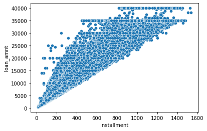

```python
sns.scatterplot(data=df,x=df['installment'],y=df['loan_amnt'])
```

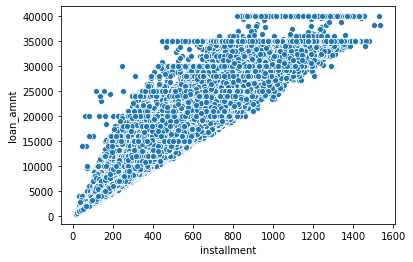

**TASK: Create a boxplot showing the relationship between the loan_status and the Loan Amount.**

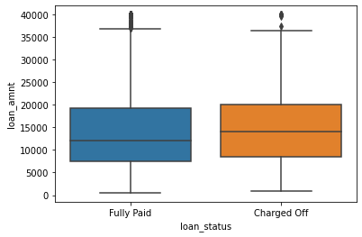

```python
sns.boxplot(data=df,x=df['loan_status'],y=df['loan_amnt'])
```

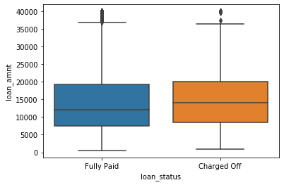

**TASK: Calculate the summary statistics for the loan amount, grouped by the loan_status.**

```python
df['loan_amnt'].describe()
```

```
count    396030.000000
mean      14113.888089
std        8357.441341
min         500.000000
25%        8000.000000
50%       12000.000000
75%       20000.000000
max       40000.000000
Name: loan_amnt, dtype: float64
```

```python
foo = df.groupby("loan_status")["loan_amnt"].describe()
foo
```

| loan_status | count | mean | std | min | 25% | 50% | 75% | max |
| --- | --- | --- | --- | --- | --- | --- | --- | --- |
| Charged Off | 77673.0 | 15126.300967 | 8505.090557 | 1000.0 | 8525.0 | 14000.0 | 20000.0 | 40000.0 |
| Fully Paid | 318357.0 | 13866.878771 | 8302.319699 | 500.0 | 7500.0 | 12000.0 | 19225.0 | 40000.0 |

Ha! It worked. Got that off RealPython. Would it work without the foo? Ah, yes, it does.

```python
df.groupby("loan_status")["loan_amnt"].describe()
```

| loan_status | count | mean | std | min | 25% | 50% | 75% | max |
| --- | --- | --- | --- | --- | --- | --- | --- | --- |
| Charged Off | 77673.0 | 15126.300967 | 8505.090557 | 1000.0 | 8525.0 | 14000.0 | 20000.0 | 40000.0 |
| Fully Paid | 318357.0 | 13866.878771 | 8302.319699 | 500.0 | 7500.0 | 12000.0 | 19225.0 | 40000.0 |

| loan_status | count | mean | std | min | 25% | 50% | 75% | max |
| --- | --- | --- | --- | --- | --- | --- | --- | --- |
| Charged Off | 77673.0 | 15126.300967 | 8505.090557 | 1000.0 | 8525.0 | 14000.0 | 20000.0 | 40000.0 |
| Fully Paid | 318357.0 | 13866.878771 | 8302.319699 | 500.0 | 7500.0 | 12000.0 | 19225.0 | 40000.0 |

**TASK: Let's explore the Grade and SubGrade columns that LendingClub attributes to the loans. What are the unique possible grades and subgrades?**

```python
df['grade'].unique()
```

```
array(['B', 'A', 'C', 'E', 'D', 'F', 'G'], dtype=object)
```

```
['A', 'B', 'C', 'D', 'E', 'F', 'G']
```

```python
df.head()
```

|  | loan_amnt | term | int_rate | installment | grade | sub_grade | emp_title | emp_length | home_ownership | annual_inc | ... | open_acc | pub_rec | revol_bal | revol_util | total_acc | initial_list_status | application_type | mort_acc | pub_rec_bankruptcies | address |
| --- | --- | --- | --- | --- | --- | --- | --- | --- | --- | --- | --- | --- | --- | --- | --- | --- | --- | --- | --- | --- | --- |
| 0 | 10000.0 | 36 months | 11.44 | 329.48 | B | B4 | Marketing | 10+ years | RENT | 117000.0 | ... | 16.0 | 0.0 | 36369.0 | 41.8 | 25.0 | w | INDIVIDUAL | 0.0 | 0.0 | 0174 Michelle Gateway\nMendozaberg, OK 22690 |
| 1 | 8000.0 | 36 months | 11.99 | 265.68 | B | B5 | Credit analyst | 4 years | MORTGAGE | 65000.0 | ... | 17.0 | 0.0 | 20131.0 | 53.3 | 27.0 | f | INDIVIDUAL | 3.0 | 0.0 | 1076 Carney Fort Apt. 347\nLoganmouth, SD 05113 |
| 2 | 15600.0 | 36 months | 10.49 | 506.97 | B | B3 | Statistician | < 1 year | RENT | 43057.0 | ... | 13.0 | 0.0 | 11987.0 | 92.2 | 26.0 | f | INDIVIDUAL | 0.0 | 0.0 | 87025 Mark Dale Apt. 269\nNew Sabrina, WV 05113 |
| 3 | 7200.0 | 36 months | 6.49 | 220.65 | A | A2 | Client Advocate | 6 years | RENT | 54000.0 | ... | 6.0 | 0.0 | 5472.0 | 21.5 | 13.0 | f | INDIVIDUAL | 0.0 | 0.0 | 823 Reid Ford\nDelacruzside, MA 00813 |
| 4 | 24375.0 | 60 months | 17.27 | 609.33 | C | C5 | Destiny Management Inc. | 9 years | MORTGAGE | 55000.0 | ... | 13.0 | 0.0 | 24584.0 | 69.8 | 43.0 | f | INDIVIDUAL | 1.0 | 0.0 | 679 Luna Roads\nGreggshire, VA 11650 |

5 rows × 27 columns

```python
df['sub_grade'].unique()
```

```
array(['B4', 'B5', 'B3', 'A2', 'C5', 'C3', 'A1', 'B2', 'C1', 'A5', 'E4',
       'A4', 'A3', 'D1', 'C2', 'B1', 'D3', 'D5', 'D2', 'E1', 'E2', 'E5',
       'F4', 'E3', 'D4', 'G1', 'F5', 'G2', 'C4', 'F1', 'F3', 'G5', 'G4',
       'F2', 'G3'], dtype=object)
```

```
['A1',
 'A2',
 'A3',
 'A4',
 'A5',
 'B1',
 'B2',
 'B3',
 'B4',
 'B5',
 'C1',
 'C2',
 'C3',
 'C4',
 'C5',
 'D1',
 'D2',
 'D3',
 'D4',
 'D5',
 'E1',
 'E2',
 'E3',
 'E4',
 'E5',
 'F1',
 'F2',
 'F3',
 'F4',
 'F5',
 'G1',
 'G2',
 'G3',
 'G4',
 'G5']
```

**TASK: Create a countplot per grade. Set the hue to the loan_status label.**

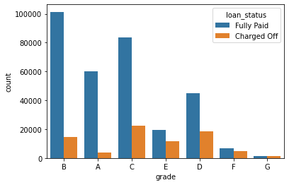

```python
sns.countplot(x=df['grade'], hue=df['loan_status'])
```

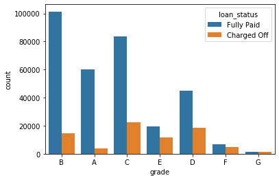

**TASK: Display a count plot per subgrade. You may need to resize for this plot and [reorder](https://seaborn.pydata.org/generated/seaborn.countplot.html#seaborn.countplot) the x axis. Feel free to edit the color palette. Explore both all loans made per subgrade as well being separated based on the loan_status. After creating this plot, go ahead and create a similar plot, but set hue="loan_status"**

Okay, a bit stumped below on how to reorder my x axis... yay, did it! Stack Overflow, this time

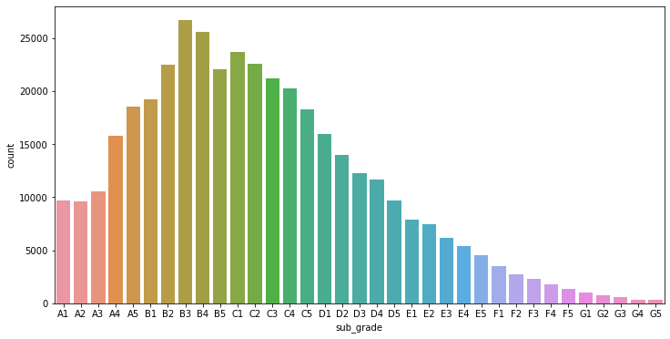

```python
plt.figure(figsize=(12,6))
sns.countplot(x=df['sub_grade'].sort_values())
```

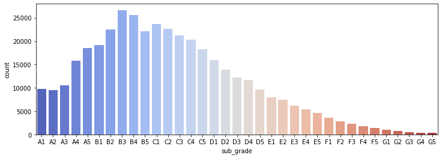

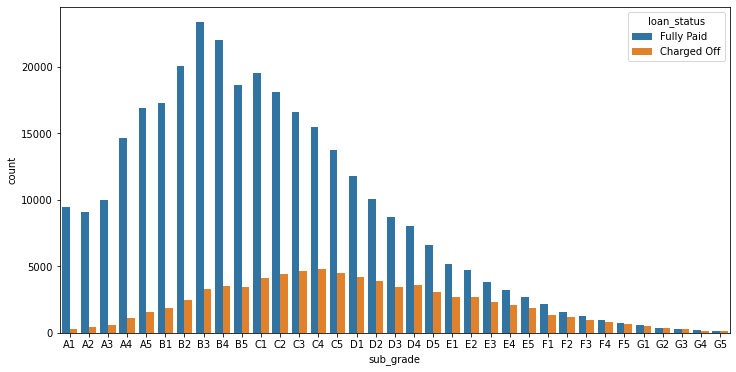

```python
plt.figure(figsize=(12,6))
sns.countplot(x=df['sub_grade'].sort_values(), hue=df['loan_status'])
```

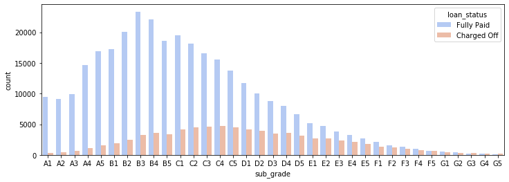

**TASK: It looks like F and G subgrades don't get paid back that often. Isloate those and recreate the countplot just for those subgrades.**

I'm going to have to look at the answers - I can't even work out what to search for. How do i isolate thise? I've tried slicing... Wow, I looked, and the answer is a long way from what I was trying.

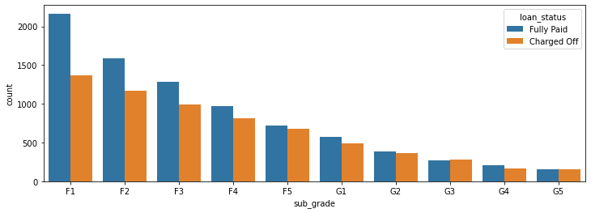

```python
# plt.figure(figsize=(12,6))
# sns.countplot(x=df['sub_grade'].sort_values(), hue=df['loan_status'])

f_and_g = df[(df['grade']=='G') | (df['grade']=='F')] #ok, I kind of follow this - but why 'or'? That's what the bar means, right?

plt.figure(figsize=(12,4))
subgrade_order = sorted(f_and_g['sub_grade'].unique())
sns.countplot(x='sub_grade',data=f_and_g,order = subgrade_order,hue='loan_status') #crikey
```

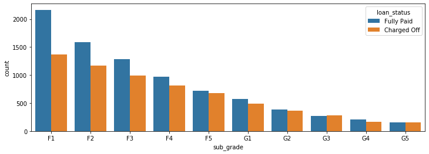

**TASK: Create a new column called 'loan_repaid' which will contain a 1 if the loan status was "Fully Paid" and a 0 if it was "Charged Off".**

So i think I need a dummy variable thing here? I'm getting tired, too quick to go the answers - and dummy variables are confusing, to me I'd never have come up with this mapping, myself - must study it

```python
# df['loan_repaid'] = pd.get_dummies(df['loan_status'])
df['loan_repaid'] = df['loan_status'].map({'Fully Paid':1,'Charged Off':0})
```

[output not shown]

```python
df[['loan_repaid','loan_status']]
```

|  | loan_repaid | loan_status |
| --- | --- | --- |
| 0 | 1 | Fully Paid |
| 1 | 1 | Fully Paid |
| 2 | 1 | Fully Paid |
| 3 | 1 | Fully Paid |
| 4 | 0 | Charged Off |
| ... | ... | ... |
| 396025 | 1 | Fully Paid |
| 396026 | 1 | Fully Paid |
| 396027 | 1 | Fully Paid |
| 396028 | 1 | Fully Paid |
| 396029 | 1 | Fully Paid |

396030 rows × 2 columns

|  | loan_repaid | loan_status |
| --- | --- | --- |
| 0 | 1 | Fully Paid |
| 1 | 1 | Fully Paid |
| 2 | 1 | Fully Paid |
| 3 | 1 | Fully Paid |
| 4 | 0 | Charged Off |
| ... | ... | ... |
| 396025 | 1 | Fully Paid |
| 396026 | 1 | Fully Paid |
| 396027 | 1 | Fully Paid |
| 396028 | 1 | Fully Paid |
| 396029 | 1 | Fully Paid |

396030 rows × 2 columns

**CHALLENGE TASK: (Note this is hard, but can be done in one line!) Create a bar plot showing the correlation of the numeric features to the new loan_repaid column. [Helpful Link](https://pandas.pydata.org/pandas-docs/stable/reference/api/pandas.DataFrame.plot.bar.html)**

```python
df.head(1) #Looking at the columns
```

|  | loan_amnt | term | int_rate | installment | grade | sub_grade | emp_title | emp_length | home_ownership | annual_inc | ... | pub_rec | revol_bal | revol_util | total_acc | initial_list_status | application_type | mort_acc | pub_rec_bankruptcies | address | loan_repaid |
| --- | --- | --- | --- | --- | --- | --- | --- | --- | --- | --- | --- | --- | --- | --- | --- | --- | --- | --- | --- | --- | --- |
| 0 | 10000.0 | 36 months | 11.44 | 329.48 | B | B4 | Marketing | 10+ years | RENT | 117000.0 | ... | 0.0 | 36369.0 | 41.8 | 25.0 | w | INDIVIDUAL | 0.0 | 0.0 | 0174 Michelle Gateway\nMendozaberg, OK 22690 | 1 |

1 rows × 28 columns

So - the response from the answers sheet is a zillion miles from what I was doing. I did initially try something with .corr() but that got me nowhere and didn;t seem to reflect the link! I'll learn more when I watch the video..

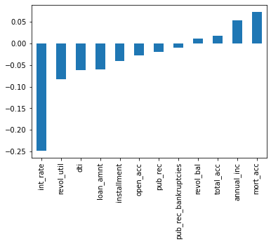

```python
# sns.barplot(data=df, x=df.select_dtypes(include=np.number),y=df['loan_repaid'])
# pd.DataFrame.plot.bar(data=df,x=df.select_dtypes(include=np.number),y=df['loan_repaid'])
# pd.DataFrame.plot.bar(x=df['loan_repaid'],y=df)
# df.plot.bar(x=df['loan_repaid'],y=df)
# ANSWER FROM EXERCISES:

df.corr()['loan_repaid'].sort_values().drop('loan_repaid').plot(kind='bar')
```

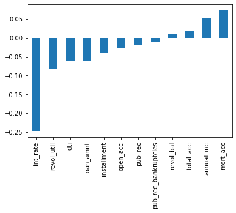

# Section 2: Data PreProcessing

**Section Goals: Remove or fill any missing data. Remove unnecessary or repetitive features. Convert categorical string features to dummy variables.**

|  | loan_amnt | term | int_rate | installment | grade | sub_grade | emp_title | emp_length | home_ownership | annual_inc | ... | pub_rec | revol_bal | revol_util | total_acc | initial_list_status | application_type | mort_acc | pub_rec_bankruptcies | address | loan_repaid |
| --- | --- | --- | --- | --- | --- | --- | --- | --- | --- | --- | --- | --- | --- | --- | --- | --- | --- | --- | --- | --- | --- |
| 0 | 10000.0 | 36 months | 11.44 | 329.48 | B | B4 | Marketing | 10+ years | RENT | 117000.0 | ... | 0.0 | 36369.0 | 41.8 | 25.0 | w | INDIVIDUAL | 0.0 | 0.0 | 0174 Michelle Gateway\nMendozaberg, OK 22690 | 1 |
| 1 | 8000.0 | 36 months | 11.99 | 265.68 | B | B5 | Credit analyst | 4 years | MORTGAGE | 65000.0 | ... | 0.0 | 20131.0 | 53.3 | 27.0 | f | INDIVIDUAL | 3.0 | 0.0 | 1076 Carney Fort Apt. 347\nLoganmouth, SD 05113 | 1 |
| 2 | 15600.0 | 36 months | 10.49 | 506.97 | B | B3 | Statistician | < 1 year | RENT | 43057.0 | ... | 0.0 | 11987.0 | 92.2 | 26.0 | f | INDIVIDUAL | 0.0 | 0.0 | 87025 Mark Dale Apt. 269\nNew Sabrina, WV 05113 | 1 |
| 3 | 7200.0 | 36 months | 6.49 | 220.65 | A | A2 | Client Advocate | 6 years | RENT | 54000.0 | ... | 0.0 | 5472.0 | 21.5 | 13.0 | f | INDIVIDUAL | 0.0 | 0.0 | 823 Reid Ford\nDelacruzside, MA 00813 | 1 |
| 4 | 24375.0 | 60 months | 17.27 | 609.33 | C | C5 | Destiny Management Inc. | 9 years | MORTGAGE | 55000.0 | ... | 0.0 | 24584.0 | 69.8 | 43.0 | f | INDIVIDUAL | 1.0 | 0.0 | 679 Luna Roads\nGreggshire, VA 11650 | 0 |

5 rows × 28 columns

# Missing Data

**Let's explore this missing data columns. We use a variety of factors to decide whether or not they would be useful, to see if we should keep, discard, or fill in the missing data.**

**TASK: What is the length of the dataframe?**

```python
len(df)
```

```
396030
```

```
396030
```

**TASK: Create a Series that displays the total count of missing values per column.**

```python
df.isnull().sum() #Already did this :-)
```

```
loan_amnt                   0
term                        0
int_rate                    0
installment                 0
grade                       0
sub_grade                   0
emp_title               22927
emp_length              18301
home_ownership              0
annual_inc                  0
verification_status         0
issue_d                     0
loan_status                 0
purpose                     0
title                    1755
dti                         0
earliest_cr_line            0
open_acc                    0
pub_rec                     0
revol_bal                   0
revol_util                276
total_acc                   0
initial_list_status         0
application_type            0
mort_acc                37795
pub_rec_bankruptcies      535
address                     0
loan_repaid                 0
dtype: int64
```

```
loan_amnt                   0
term                        0
int_rate                    0
installment                 0
grade                       0
sub_grade                   0
emp_title               22927
emp_length              18301
home_ownership              0
annual_inc                  0
verification_status         0
issue_d                     0
loan_status                 0
purpose                     0
title                    1755
dti                         0
earliest_cr_line            0
open_acc                    0
pub_rec                     0
revol_bal                   0
revol_util                276
total_acc                   0
initial_list_status         0
application_type            0
mort_acc                37795
pub_rec_bankruptcies      535
address                     0
loan_repaid                 0
dtype: int64
```

Hmm. Don't know what I'm doing here. Again, I'm struggling with getting the numerics - I need to sort that out. Okay, and again I'm not sure I understand the solution version

```python
# df = df.apply(lambda x: x/sum(x)*100, axis=1)
100* df.isnull().sum()/len(df)
```

```
loan_amnt               0.000000
term                    0.000000
int_rate                0.000000
installment             0.000000
grade                   0.000000
sub_grade               0.000000
emp_title               5.789208
emp_length              4.621115
home_ownership          0.000000
annual_inc              0.000000
verification_status     0.000000
issue_d                 0.000000
loan_status             0.000000
purpose                 0.000000
title                   0.443148
dti                     0.000000
earliest_cr_line        0.000000
open_acc                0.000000
pub_rec                 0.000000
revol_bal               0.000000
revol_util              0.069692
total_acc               0.000000
initial_list_status     0.000000
application_type        0.000000
mort_acc                9.543469
pub_rec_bankruptcies    0.135091
address                 0.000000
loan_repaid             0.000000
dtype: float64
```

**TASK: Convert this Series to be in term of percentage of the total DataFrame**

```
loan_amnt               0.000000
term                    0.000000
int_rate                0.000000
installment             0.000000
grade                   0.000000
sub_grade               0.000000
emp_title               5.789208
emp_length              4.621115
home_ownership          0.000000
annual_inc              0.000000
verification_status     0.000000
issue_d                 0.000000
loan_status             0.000000
purpose                 0.000000
title                   0.443148
dti                     0.000000
earliest_cr_line        0.000000
open_acc                0.000000
pub_rec                 0.000000
revol_bal               0.000000
revol_util              0.069692
total_acc               0.000000
initial_list_status     0.000000
application_type        0.000000
mort_acc                9.543469
pub_rec_bankruptcies    0.135091
address                 0.000000
loan_repaid             0.000000
dtype: float64
```

**TASK: Let's examine emp_title and emp_length to see whether it will be okay to drop them. Print out their feature information using the feat_info() function from the top of this notebook.**

```python
feat_info('emp_title')
feat_info('emp_length')
```

```
The job title supplied by the Borrower when applying for the loan.*
Employment length in years. Possible values are between 0 and 10 where 0 means less than one year and 10 means ten or more years.
```

```
The job title supplied by the Borrower when applying for the loan.*


Employment length in years. Possible values are between 0 and 10 where 0 means less than one year and 10 means ten or more years.
```

**TASK: How many unique employment job titles are there?**

```python
df['emp_title'].nunique()
```

```
173105
```

```
173105
```

[output not shown]

**TASK: Realistically there are too many unique job titles to try to convert this to a dummy variable feature. Let's remove that emp_title column.**

```python
df.drop(['emp_title'], axis=1)
```

|  | loan_amnt | term | int_rate | installment | grade | sub_grade | emp_length | home_ownership | annual_inc | verification_status | ... | pub_rec | revol_bal | revol_util | total_acc | initial_list_status | application_type | mort_acc | pub_rec_bankruptcies | address | loan_repaid |
| --- | --- | --- | --- | --- | --- | --- | --- | --- | --- | --- | --- | --- | --- | --- | --- | --- | --- | --- | --- | --- | --- |
| 0 | 10000.0 | 36 months | 11.44 | 329.48 | B | B4 | 10+ years | RENT | 117000.0 | Not Verified | ... | 0.0 | 36369.0 | 41.8 | 25.0 | w | INDIVIDUAL | 0.0 | 0.0 | 0174 Michelle Gateway\nMendozaberg, OK 22690 | 1 |
| 1 | 8000.0 | 36 months | 11.99 | 265.68 | B | B5 | 4 years | MORTGAGE | 65000.0 | Not Verified | ... | 0.0 | 20131.0 | 53.3 | 27.0 | f | INDIVIDUAL | 3.0 | 0.0 | 1076 Carney Fort Apt. 347\nLoganmouth, SD 05113 | 1 |
| 2 | 15600.0 | 36 months | 10.49 | 506.97 | B | B3 | < 1 year | RENT | 43057.0 | Source Verified | ... | 0.0 | 11987.0 | 92.2 | 26.0 | f | INDIVIDUAL | 0.0 | 0.0 | 87025 Mark Dale Apt. 269\nNew Sabrina, WV 05113 | 1 |
| 3 | 7200.0 | 36 months | 6.49 | 220.65 | A | A2 | 6 years | RENT | 54000.0 | Not Verified | ... | 0.0 | 5472.0 | 21.5 | 13.0 | f | INDIVIDUAL | 0.0 | 0.0 | 823 Reid Ford\nDelacruzside, MA 00813 | 1 |
| 4 | 24375.0 | 60 months | 17.27 | 609.33 | C | C5 | 9 years | MORTGAGE | 55000.0 | Verified | ... | 0.0 | 24584.0 | 69.8 | 43.0 | f | INDIVIDUAL | 1.0 | 0.0 | 679 Luna Roads\nGreggshire, VA 11650 | 0 |
| ... | ... | ... | ... | ... | ... | ... | ... | ... | ... | ... | ... | ... | ... | ... | ... | ... | ... | ... | ... | ... | ... |
| 396025 | 10000.0 | 60 months | 10.99 | 217.38 | B | B4 | 2 years | RENT | 40000.0 | Source Verified | ... | 0.0 | 1990.0 | 34.3 | 23.0 | w | INDIVIDUAL | 0.0 | 0.0 | 12951 Williams Crossing\nJohnnyville, DC 30723 | 1 |
| 396026 | 21000.0 | 36 months | 12.29 | 700.42 | C | C1 | 5 years | MORTGAGE | 110000.0 | Source Verified | ... | 0.0 | 43263.0 | 95.7 | 8.0 | f | INDIVIDUAL | 1.0 | 0.0 | 0114 Fowler Field Suite 028\nRachelborough, LA... | 1 |
| 396027 | 5000.0 | 36 months | 9.99 | 161.32 | B | B1 | 10+ years | RENT | 56500.0 | Verified | ... | 0.0 | 32704.0 | 66.9 | 23.0 | f | INDIVIDUAL | 0.0 | 0.0 | 953 Matthew Points Suite 414\nReedfort, NY 70466 | 1 |
| 396028 | 21000.0 | 60 months | 15.31 | 503.02 | C | C2 | 10+ years | MORTGAGE | 64000.0 | Verified | ... | 0.0 | 15704.0 | 53.8 | 20.0 | f | INDIVIDUAL | 5.0 | 0.0 | 7843 Blake Freeway Apt. 229\nNew Michael, FL 2... | 1 |
| 396029 | 2000.0 | 36 months | 13.61 | 67.98 | C | C2 | 10+ years | RENT | 42996.0 | Verified | ... | 0.0 | 4292.0 | 91.3 | 19.0 | f | INDIVIDUAL | NaN | 0.0 | 787 Michelle Causeway\nBriannaton, AR 48052 | 1 |

396030 rows × 27 columns

**TASK: Create a count plot of the emp_length feature column. Challenge: Sort the order of the values.**

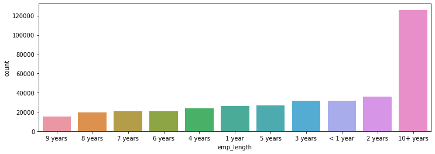

```python
plt.figure(figsize=(12,4))
sns.countplot(data=df, x=df['emp_length'], order = df['emp_length'].value_counts(ascending=True).index)
```

[output not shown]

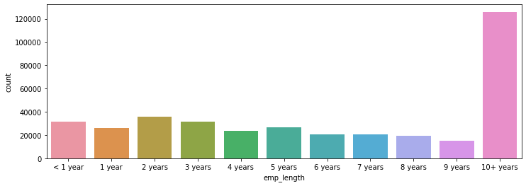

**TASK: Plot out the countplot with a hue separating Fully Paid vs Charged Off**

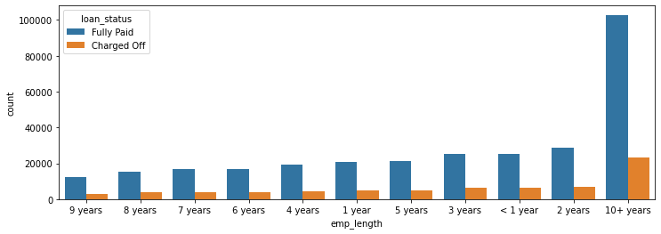

```python
plt.figure(figsize=(12,4))
sns.countplot(data=df, x=df['emp_length'], order = df['emp_length'].value_counts(ascending=True).index, hue='loan_status')
#hang on! my order has gone - same code as before. No, actually it was never right.
```

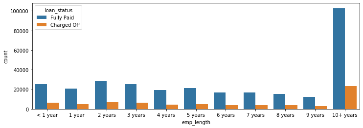

**CHALLENGE TASK: This still doesn't really inform us if there is a strong relationship between employment length and being charged off, what we want is the percentage of charge offs per category. Essentially informing us what percent of people per employment category didn't pay back their loan. There are a multitude of ways to create this Series. Once you've created it, see if visualize it with a [bar plot](https://pandas.pydata.org/pandas-docs/version/0.23.4/generated/pandas.DataFrame.plot.html). This may be tricky, refer to solutions if you get stuck on creating this Series.**

```python
emp_co = df[df['loan_status']=="Charged Off"].groupby("emp_length").count()['loan_status']
```

```python
emp_fp = df[df['loan_status']=="Fully Paid"].groupby("emp_length").count()['loan_status']
```

```python
emp_len = emp_co/emp_fp
```

```python
emp_len #I looked at solutions for this but I'm still not sure of it.
```

```
emp_length
1 year       0.248649
10+ years    0.225770
2 years      0.239560
3 years      0.242593
4 years      0.238213
5 years      0.237911
6 years      0.233341
7 years      0.241887
8 years      0.249625
9 years      0.250735
< 1 year     0.260830
Name: loan_status, dtype: float64
```

```
emp_length
1 year       0.248649
10+ years    0.225770
2 years      0.239560
3 years      0.242593
4 years      0.238213
5 years      0.237911
6 years      0.233341
7 years      0.241887
8 years      0.249625
9 years      0.250735
< 1 year     0.260830
Name: loan_status, dtype: float64
```

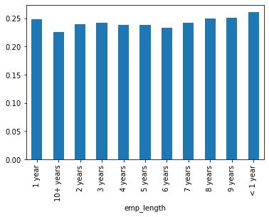

```python
emp_len.plot(kind='bar')
```

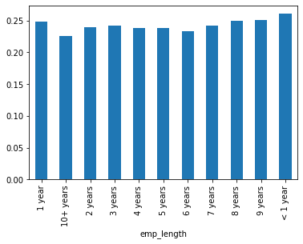

**TASK: Charge off rates are extremely similar across all employment lengths. Go ahead and drop the emp_length column.**

```python
# df.drop(['emp_length'], axis=1) #ah, i see where I went wrong - I wondered why they were still here!
```

[output not shown]

```python
df = df.drop('emp_title',axis=1)
```

**TASK: Revisit the DataFrame to see what feature columns still have missing data.**

```python
df.head(1)
```

[output not shown]

```python
df.isnull().sum()
```

```
loan_amnt                   0
term                        0
int_rate                    0
installment                 0
grade                       0
sub_grade                   0
emp_length              18301
home_ownership              0
annual_inc                  0
verification_status         0
issue_d                     0
loan_status                 0
purpose                     0
title                    1755
dti                         0
earliest_cr_line            0
open_acc                    0
pub_rec                     0
revol_bal                   0
revol_util                276
total_acc                   0
initial_list_status         0
application_type            0
mort_acc                37795
pub_rec_bankruptcies      535
address                     0
loan_repaid                 0
dtype: int64
```

```
loan_amnt                   0
term                        0
int_rate                    0
installment                 0
grade                       0
sub_grade                   0
home_ownership              0
annual_inc                  0
verification_status         0
issue_d                     0
loan_status                 0
purpose                     0
title                    1755
dti                         0
earliest_cr_line            0
open_acc                    0
pub_rec                     0
revol_bal                   0
revol_util                276
total_acc                   0
initial_list_status         0
application_type            0
mort_acc                37795
pub_rec_bankruptcies      535
address                     0
loan_repaid                 0
dtype: int64
```

**TASK: Review the title column vs the purpose column. Is this repeated information?**

```python
df['title'].head()
```

```
0                   Vacation
1         Debt consolidation
2    Credit card refinancing
3    Credit card refinancing
4      Credit Card Refinance
Name: title, dtype: object
```

```python
df['purpose'].head()
```

```
0              vacation
1    debt_consolidation
2           credit_card
3           credit_card
4           credit_card
Name: purpose, dtype: object
```

```
0              vacation
1    debt_consolidation
2           credit_card
3           credit_card
4           credit_card
5    debt_consolidation
6      home_improvement
7           credit_card
8    debt_consolidation
9    debt_consolidation
Name: purpose, dtype: object
```

```python
df['title'].head(10)
```

```
0                   Vacation
1         Debt consolidation
2    Credit card refinancing
3    Credit card refinancing
4      Credit Card Refinance
5         Debt consolidation
6           Home improvement
7       No More Credit Cards
8         Debt consolidation
9         Debt Consolidation
Name: title, dtype: object
```

**TASK: The title column is simply a string subcategory/description of the purpose column. Go ahead and drop the title column.**

```python
df = df.drop('title',axis=1)
```

**NOTE: This is one of the hardest parts of the project! Refer to the solutions video if you need guidance, feel free to fill or drop the missing values of the mort_acc however you see fit! Here we're going with a very specific approach.**

**TASK: Find out what the mort_acc feature represents**

```python
feat_info('mort_acc')
```

```
Number of mortgage accounts.
```

```
Number of mortgage accounts.
```

**TASK: Create a value_counts of the mort_acc column.**

```python
df['mort_acc'].value_counts()
```

```
0.0     139777
1.0      60416
2.0      49948
3.0      38049
4.0      27887
5.0      18194
6.0      11069
7.0       6052
8.0       3121
9.0       1656
10.0       865
11.0       479
12.0       264
13.0       146
14.0       107
15.0        61
16.0        37
17.0        22
18.0        18
19.0        15
20.0        13
24.0        10
22.0         7
21.0         4
25.0         4
27.0         3
23.0         2
31.0         2
26.0         2
32.0         2
28.0         1
34.0         1
30.0         1
Name: mort_acc, dtype: int64
```

```
0.0     139777
1.0      60416
2.0      49948
3.0      38049
4.0      27887
5.0      18194
6.0      11069
7.0       6052
8.0       3121
9.0       1656
10.0       865
11.0       479
12.0       264
13.0       146
14.0       107
15.0        61
16.0        37
17.0        22
18.0        18
19.0        15
20.0        13
24.0        10
22.0         7
21.0         4
25.0         4
27.0         3
23.0         2
32.0         2
26.0         2
31.0         2
30.0         1
28.0         1
34.0         1
Name: mort_acc, dtype: int64
```

**TASK: There are many ways we could deal with this missing data. We could attempt to build a simple model to fill it in, such as a linear model, we could just fill it in based on the mean of the other columns, or you could even bin the columns into categories and then set NaN as its own category. There is no 100% correct approach! Let's review the other columsn to see which most highly correlates to mort_acc**

```python
# df.corr(df['mort_acc'])
print("Correlation with the mort_acc column")
df.corr()['mort_acc'].sort_values() #okay, this is interesting - put the column you want to correlate with outside the ()
#and then .sort_values(). I'll have a look at it without sort_values too. (Unsurprisingly, it's just out of order!)
```

```
Correlation with the mort_acc column
```

```
loan_amnt               0.222315
int_rate               -0.082583
installment             0.193694
annual_inc              0.236320
dti                    -0.025439
open_acc                0.109205
pub_rec                 0.011552
revol_bal               0.194925
revol_util              0.007514
total_acc               0.381072
mort_acc                1.000000
pub_rec_bankruptcies    0.027239
loan_repaid             0.073111
Name: mort_acc, dtype: float64
```

```
Correlation with the mort_acc column
```

```
int_rate               -0.082583
dti                    -0.025439
revol_util              0.007514
pub_rec                 0.011552
pub_rec_bankruptcies    0.027239
loan_repaid             0.073111
open_acc                0.109205
installment             0.193694
revol_bal               0.194925
loan_amnt               0.222315
annual_inc              0.236320
total_acc               0.381072
mort_acc                1.000000
Name: mort_acc, dtype: float64
```

**TASK: Looks like the total_acc feature correlates with the mort_acc , this makes sense! Let's try this fillna() approach. We will group the dataframe by the total_acc and calculate the mean value for the mort_acc per total_acc entry. To get the result below:**

I don't understand what I'm trying to do here. Well, maybe... okay, I was in the right direction. I forget to do it all in one go. I still find it awkward that the ['mort_acc'] is just stuck on the end there, outside the mean(). I have to remember that.

```python
# df.groupby(df['total_acc'])
df.groupby('total_acc').mean()['mort_acc']
```

```
total_acc
2.0      0.000000
3.0      0.052023
4.0      0.066743
5.0      0.103289
6.0      0.151293
           ...
124.0    1.000000
129.0    1.000000
135.0    3.000000
150.0    2.000000
151.0    0.000000
Name: mort_acc, Length: 118, dtype: float64
```

```
Mean of mort_acc column per total_acc
```

```
total_acc
2.0      0.000000
3.0      0.052023
4.0      0.066743
5.0      0.103289
6.0      0.151293
           ...
124.0    1.000000
129.0    1.000000
135.0    3.000000
150.0    2.000000
151.0    0.000000
Name: mort_acc, Length: 118, dtype: float64
```

**CHALLENGE TASK: Let's fill in the missing mort_acc values based on their total_acc value. If the mort_acc is missing, then we will fill in that missing value with the mean value corresponding to its total_acc value from the Series we created above. This involves using an .apply() method with two columns. Check out the link below for more info, or review the solutions video/notebook.**

[Helpful Link](https://stackoverflow.com/questions/13331698/how-to-apply-a-function-to-two-columns-of-pandas-dataframe)

```python
# def mean_total(mort_acc,total_acc):
#     if mort_acc == 0.0:
#         mort_acc = total_acc.mean() #nah, I need to get the mean, as above. So - what?

# df['mort_acc'] = df.apply(lambda x: mean_total(df.mort_acc, df.total_acc), axis=1)
```

```python
total_acc_avg = df.groupby('total_acc').mean()['mort_acc'] #so this is just the code from above, assigned to a variable
```

```python
total_acc_avg[2.0] #i don;t get what this is doing
```

```
0.0
```

```python
def fill_mort_acc(total_acc,mort_acc):
    '''
    Accepts the total_acc and mort_acc values for the row.
    Checks if the mort_acc is NaN , if so, it returns the avg mort_acc value
    for the corresponding total_acc value for that row.

    total_acc_avg here should be a Series or dictionary containing the mapping of the
    groupby averages of mort_acc per total_acc values.
    '''
    if np.isnan(mort_acc):
        return total_acc_avg[total_acc]
    else:
        return mort_acc #okay, so I wasn't TOO far off in this
```

```python
df['mort_acc'] = df.apply(lambda x: fill_mort_acc(x['total_acc'], x['mort_acc']), axis=1)
#I'm not totally on top of lambdas but okay, I can see this
```

```python
df.isnull().sum()
```

[output not shown]

```
loan_amnt                 0
term                      0
int_rate                  0
installment               0
grade                     0
sub_grade                 0
home_ownership            0
annual_inc                0
verification_status       0
issue_d                   0
loan_status               0
purpose                   0
dti                       0
earliest_cr_line          0
open_acc                  0
pub_rec                   0
revol_bal                 0
revol_util              276
total_acc                 0
initial_list_status       0
application_type          0
mort_acc                  0
pub_rec_bankruptcies    535
address                   0
loan_repaid               0
dtype: int64
```

**TASK: revol_util and the pub_rec_bankruptcies have missing data points, but they account for less than 0.5% of the total data. Go ahead and remove the rows that are missing those values in those columns with dropna().**

```python
df = df.dropna()
```

```python
df.isnull().sum()
```

```
loan_amnt               0
term                    0
int_rate                0
installment             0
grade                   0
sub_grade               0
emp_length              0
home_ownership          0
annual_inc              0
verification_status     0
issue_d                 0
loan_status             0
purpose                 0
dti                     0
earliest_cr_line        0
open_acc                0
pub_rec                 0
revol_bal               0
revol_util              0
total_acc               0
initial_list_status     0
application_type        0
mort_acc                0
pub_rec_bankruptcies    0
address                 0
loan_repaid             0
dtype: int64
```

```
loan_amnt               0
term                    0
int_rate                0
installment             0
grade                   0
sub_grade               0
home_ownership          0
annual_inc              0
verification_status     0
issue_d                 0
loan_status             0
purpose                 0
dti                     0
earliest_cr_line        0
open_acc                0
pub_rec                 0
revol_bal               0
revol_util              0
total_acc               0
initial_list_status     0
application_type        0
mort_acc                0
pub_rec_bankruptcies    0
address                 0
loan_repaid             0
dtype: int64
```

## Categorical Variables and Dummy Variables

**We're done working with the missing data! Now we just need to deal with the string values due to the categorical columns.**

**TASK: List all the columns that are currently non-numeric. [Helpful Link](https://stackoverflow.com/questions/22470690/get-list-of-pandas-dataframe-columns-based-on-data-type)**

[Another very useful method call](https://pandas.pydata.org/pandas-docs/stable/reference/api/pandas.DataFrame.select_dtypes.html)

```python
# wordy = list(df.select_dtypes(['string']).columns)
# wordy
df.select_dtypes(include=['string'])
```

| 0 |
| --- |
| 1 |
| 2 |
| 3 |
| 4 |
| ... |
| 396025 |
| 396026 |
| 396027 |
| 396028 |
| 396029 |

376929 rows × 0 columns

```python
new = list(df.select_dtypes(['string']).columns)
new
```

```
[]
```

```
Index(['term', 'grade', 'sub_grade', 'home_ownership', 'verification_status',
       'issue_d', 'loan_status', 'purpose', 'earliest_cr_line',
       'initial_list_status', 'application_type', 'address'],
      dtype='object')
```

**Let's now go through all the string features to see what we should do with them.**

### term feature

**TASK: Convert the term feature into either a 36 or 60 integer numeric data type using .apply() or .map().**

```python
def month_count(months):
    for x in months:
        if x[0] == 36:
            return 36
        else:
            return 60
```

```python
df['term'] = df['term'].apply(lambda term: int(term[:3]))
```

[output not shown]

[output not shown]

### grade feature

**TASK: We already know grade is part of sub_grade, so just drop the grade feature.**

```python
df = df.drop('grade',axis=1)
```

**TASK: Convert the subgrade into dummy variables. Then concatenate these new columns to the original dataframe. Remember to drop the original subgrade column and to add drop_first=True to your get_dummies call.**

```python
subgrade_dummies = pd.get_dummies(df['sub_grade'],drop_first=True)
```

```python
df = pd.concat([df.drop('sub_grade',axis=1),subgrade_dummies],axis=1)
```

[output not shown]

[output not shown]

### verification_status, application_type,initial_list_status,purpose

**TASK: Convert these columns: ['verification_status', 'application_type','initial_list_status','purpose'] into dummy variables and concatenate them with the original dataframe. Remember to set drop_first=True and to drop the original columns.**

```python
dummies = pd.get_dummies(df[['verification_status', 'application_type','initial_list_status','purpose' ]],drop_first=True)
df = df.drop(['verification_status', 'application_type','initial_list_status','purpose'],axis=1)
df = pd.concat([df,dummies],axis=1)
```

[output not shown]

```python
df.columns
```

```
Index(['loan_amnt', 'term', 'int_rate', 'installment', 'emp_length',
       'home_ownership', 'annual_inc', 'issue_d', 'loan_status', 'dti',
       ...
       'home_improvement', 'house', 'major_purchase', 'medical', 'moving',
       'other', 'renewable_energy', 'small_business', 'vacation', 'wedding'],
      dtype='object', length=106)
```

### home_ownership

**TASK:Review the value_counts for the home_ownership column.**

```python
df['home_ownership'].value_counts()
```

```
MORTGAGE    189448
RENT        153075
OWN          34268
OTHER          107
NONE            28
ANY              3
Name: home_ownership, dtype: int64
```

```
MORTGAGE    198022
RENT        159395
OWN          37660
OTHER          110
NONE            29
ANY              3
Name: home_ownership, dtype: int64
```

**TASK: Convert these to dummy variables, but [replace](https://pandas.pydata.org/pandas-docs/stable/reference/api/pandas.DataFrame.replace.html) NONE and ANY with OTHER, so that we end up with just 4 categories, MORTGAGE, RENT, OWN, OTHER. Then concatenate them with the original dataframe. Remember to set drop_first=True and to drop the original columns.**

```python
df['home_ownership']=df['home_ownership'].replace(['NONE', 'ANY'], 'OTHER')

dummies = pd.get_dummies(df['home_ownership'],drop_first=True)
df = df.drop('home_ownership',axis=1)
df = pd.concat([df,dummies],axis=1)
```

### address

**TASK: Let's feature engineer a zip code column from the address in the data set. Create a column called 'zip_code' that extracts the zip code from the address column.**

```python
df['address'].head()
```

```
0       0174 Michelle Gateway\nMendozaberg, OK 22690
1    1076 Carney Fort Apt. 347\nLoganmouth, SD 05113
2    87025 Mark Dale Apt. 269\nNew Sabrina, WV 05113
3              823 Reid Ford\nDelacruzside, MA 00813
4               679 Luna Roads\nGreggshire, VA 11650
Name: address, dtype: object
```

```python
df['zip_code']=df['address'].apply(lambda address:address[-5:])
```

```python
df['zip_code'].head()
```

```
0    22690
1    05113
2    05113
3    00813
4    11650
Name: zip_code, dtype: object
```

**TASK: Now make this zip_code column into dummy variables using pandas. Concatenate the result and drop the original zip_code column along with dropping the address column.**

```python
dummies = pd.get_dummies(df['zip_code'],drop_first=True)
df = df.drop(['zip_code','address'],axis=1)
df = pd.concat([df,dummies],axis=1)
```

### issue_d

**TASK: This would be data leakage, we wouldn't know beforehand whether or not a loan would be issued when using our model, so in theory we wouldn't have an issue_date, drop this feature.**

```python
df = df.drop('issue_d',axis=1)
```

```python
df.columns
```

```
Index(['loan_amnt', 'term', 'int_rate', 'installment', 'emp_length',
       'annual_inc', 'loan_status', 'dti', 'earliest_cr_line', 'open_acc',
       ...
       'RENT', '05113', '11650', '22690', '29597', '30723', '48052', '70466',
       '86630', '93700'],
      dtype='object', length=115)
```

### earliest_cr_line

**TASK: This appears to be a historical time stamp feature. Extract the year from this feature using a .apply function, then convert it to a numeric feature. Set this new data to a feature column called 'earliest_cr_year'.Then drop the earliest_cr_line feature.**

```python
df['earliest_cr_line'].head()
```

```
0    Jun-1990
1    Jul-2004
2    Aug-2007
3    Sep-2006
4    Mar-1999
Name: earliest_cr_line, dtype: object
```

```python
df['earliest_cr_year']=df['earliest_cr_line'].apply(lambda earliest_cr_line:int(earliest_cr_line[-4:]))
```

```python
df['earliest_cr_year'].head()
```

```
0    1990
1    2004
2    2007
3    2006
4    1999
Name: earliest_cr_year, dtype: int64
```

```python
df = df.drop('emp_length',axis=1)
```

```python
df.head()
```

[output not shown]

5 rows × 113 columns

## Train Test Split

**TASK: Import train_test_split from sklearn.**

```python
from sklearn.model_selection import train_test_split
```

**TASK: drop the load_status column we created earlier, since its a duplicate of the loan_repaid column. We'll use the loan_repaid column since its already in 0s and 1s.**

```python
df = df.drop('loan_status',axis=1)
```

[output not shown]

**TASK: Set X and y variables to the .values of the features and label.**

```python
X = df.drop('loan_repaid',axis=1).values
y = df['loan_repaid'].values
```

# OPTIONAL

## Grabbing a Sample for Training Time

```python
df = df.sample(frac=0.1,random_state=101)
print(len(df))
```

[output not shown]

**TASK: Perform a train/test split with test_size=0.2 and a random_state of 101.**

```python
X_train, X_test, y_train, y_test = train_test_split(X, y, test_size=0.2, random_state=101)
```

## Normalizing the Data

**TASK: Use a MinMaxScaler to normalize the feature data X_train and X_test. Recall we don't want data leakge from the test set so we only fit on the X_train data.**

```python
from sklearn.preprocessing import MinMaxScaler
```

```python
scaler = MinMaxScaler()
```

```python
X_train = scaler.fit_transform(X_train)
```

```python
X_test = scaler.transform(X_test) #note - not fitting on the x-test
```

# Creating the Model

**TASK: Run the cell below to import the necessary Keras functions.**

So why is there no module called tensorflow? Maybe I don't have it installed? Looks like I don't (below). I don't want to install yet more - I'll just add the code as though I can run it.

```python
conda list
```

[output not shown]

[output cut: 291 more lines]

[output not shown]

```python
import tensorflow as tf
from tensorflow.keras.models import Sequential
from tensorflow.keras.layers import Dense, Activation,Dropout
from tensorflow.keras.constraints import max_norm
```

[output not shown]

**TASK: Build a sequential model to will be trained on the data. You have unlimited options here, but here is what the solution uses: a model that goes 78 --> 39 --> 19--> 1 output neuron. OPTIONAL: Explore adding [Dropout layers](https://keras.io/layers/core/) 1) [2](https://towardsdatascience.com/machine-learning-part-20-dropout-keras-layers-explained-8c9f6dc4c9ab)**

```python
# CODE HERE
model = Sequential()

# input layer
model.add(Dense(80,  activation='relu'))
model.add(Dropout(0.2))

# hidden layer
model.add(Dense(40, activation='relu'))
model.add(Dropout(0.2))

# hidden layer
model.add(Dense(20, activation='relu'))
model.add(Dropout(0.2))

# output layer
model.add(Dense(units=1,activation='sigmoid'))

# Compile model
model.compile(loss='binary_crossentropy', optimizer='adam')
```

**TASK: Fit the model to the training data for at least 25 epochs. Also add in the validation data for later plotting. Optional: add in a batch_size of 256.**

```python
model.fit(x=X_train,
          y=y_train,
          epochs=50,
          batch_size=256,
          validation_data=(X_test, y_test),
          )
```

[output not shown]

[output not shown]

**TASK: OPTIONAL: Save your model.**

```python
from tensorflow.keras.models import load_model
```

```python
model.save('full_data_project_model.h5')
```

# Section 3: Evaluating Model Performance.

**TASK: Plot out the validation loss versus the training loss.**

```python
losses = pd.DataFrame(model.history.history)
```

[figure not shown]

```python
losses[['loss','val_loss']].plot()
```

**TASK: Create predictions from the X_test set and display a classification report and confusion matrix for the X_test set.**

```python
from sklearn.metrics import classification_report,confusion_matrix
```

```python
predictions = model.predict_classes(X_test)
```

```python
print(classification_report(y_test,predictions))
```

[output not shown]

confusion_matrix(y_test,predictions)

```
array([[ 6850,  8808],
       [  100, 63286]], dtype=int64)
```

**TASK: Given the customer below, would you offer this person a loan?**

```python
import random
random.seed(101)
random_ind = random.randint(0,len(df))

new_customer = df.drop('loan_repaid',axis=1).iloc[random_ind]
new_customer
```

[output not shown]

```python
model.predict_classes(new_customer.values.reshape(1,78))
```

[output not shown]

**TASK: Now check, did this person actually end up paying back their loan?**

```python
df.iloc[random_ind]['loan_repaid']
```

[output not shown]

```
1.0
```